# Regressão logística

Pedro S.R. Martins

2023-04-26

# Regressão logística

O que esperar para o encontro de hoje?  
**Teoria**

- Quando usar regressão logística
- Diferenças entre regressão logística e regressão linear
- Usos da regressão logística
- Problemas ao usar regressão logística
- Pressupostos da regressão logística
- Coeficientes da regressão logística e interpretação
- Avaliação do modelo (ajuste e outras métricas)

**Prática**

- Regressão logística no R
- Avaliação de pressupostos
- Breve introdução a outliers

# Quando usar regressão logística

- O primeiro passo para entender o uso da regressão logística é pensar na sua variável dependente e qual sua distribuição;
- Esse é o primeiro passo para começar a entender modelos lineares generalizados (*mesmo que muitas vezes não seja ensinado assim*)

[figure not shown]

# Quando usar regressão logística

- Regressão logística é o tipo de ferramenta que usamos quando nossa variável dependente (VD, DV ou Y) é categórica:
  - Com apenas duas categorias: regressão logística binária;
  - Com 3+ categorias: regressão logística multinomial;
  - Categorias **ordenadas**: regressão logística ordinal (*proportional odds regression*)
- Exemplos de $Y$ categórico:
  - Tem ou não doença (ou diagnóstico)
  - Passou ou não de ano
  - Acertou ou não uma questão
  - Apoia ou não cotas

# Quando usar regressão logística

- De pouquinho, vamos pegando um pouco dos modelos generalizados
- A ideia não é de que existem apenas duas distribuições no mundo, a normal e a não normal
- Para variáveis categóricas, como no caso do nosso $Y$ hipotético, poderíamos assumir que existe uma distribuição subjacente que recebe o nome de binomial ou Bernoulli (no caso especial em que os valores estão restritos a [0,1])

$$Y \sim b(n, p) \equiv Y \sim
Bern(p)$$

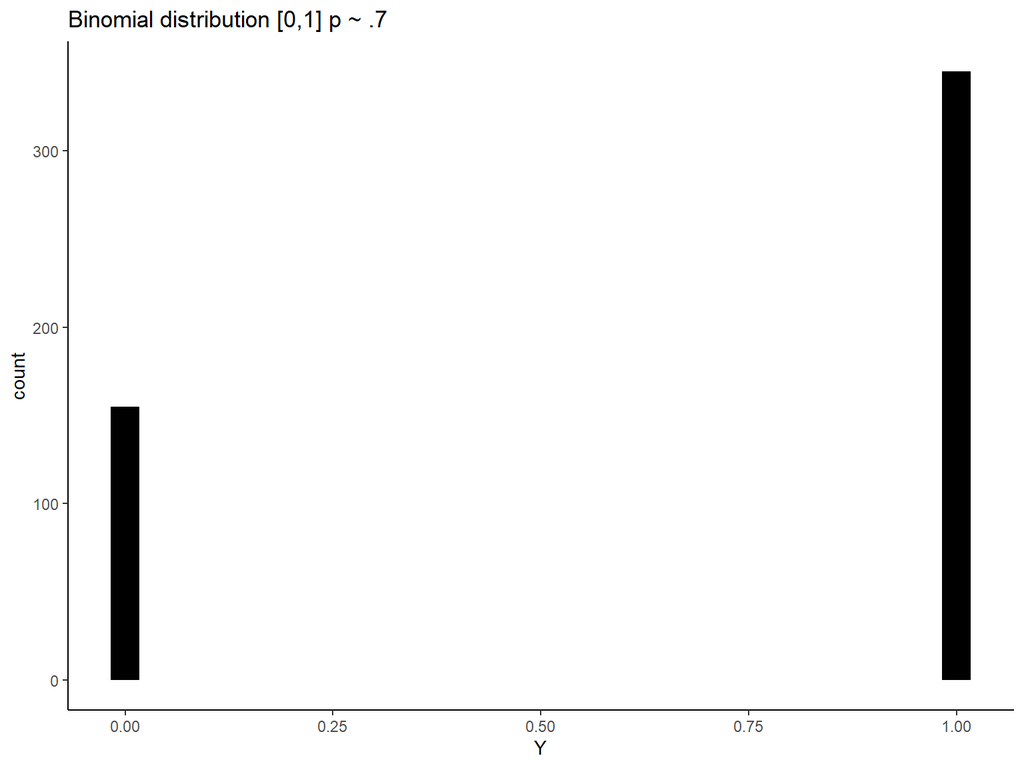

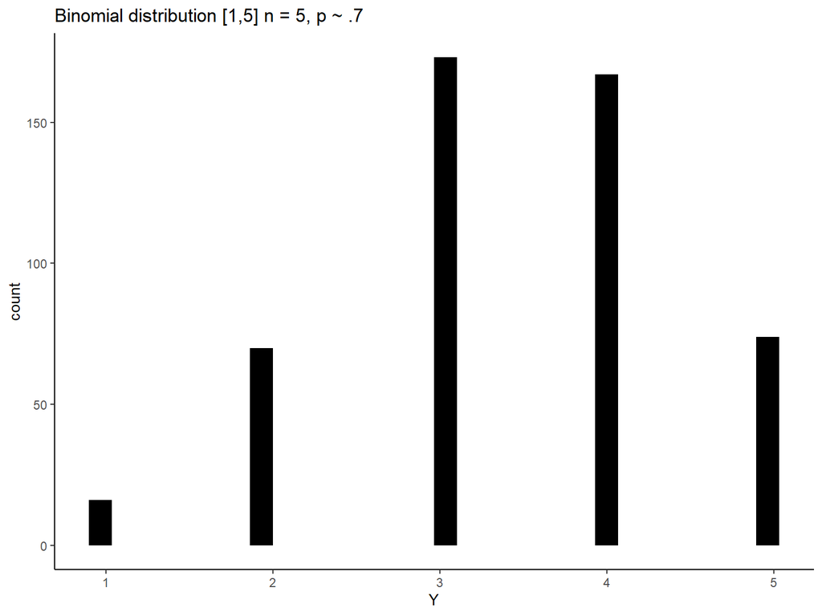

# Diferenças entre regressão logística e regressão linear

- Regressão linear (OLS) normalmente apresenta a seguinte carinha (como vimos anterioremente):

$$\hat{y}_{i} = \beta_{0} +
\beta_{1}x_{1i} +\beta_{n}x_{ni} + e_{i}$$

- Utilizar esse tipo de modelo para um $y$ dicotômico (ou categórico) pode gerar resultados esquisitos, para dizer o mínimo
- Devemos ter cuidado em relação a isso, pois os programas não fazem essa distinção pra gente e alguns aceitam variáveis categóricas dentro do comando de regressão linear

# Diferenças entre regressão logística e regressão linear

- Por que isso acontece? Por que a equação não é adequada?
- Entre outros motivos, esse tipo de modelo tem muitos pressupostos, como vimos anteriormente
- Um dos *principais* pressupostos violados é o de linearidade

# Diferenças entre regressão logística e regressão linear

- Quando trabalhamos com a regressão logística, não vamos tenta explicar $Y$ *per se*, mas sim a $P(Y)$

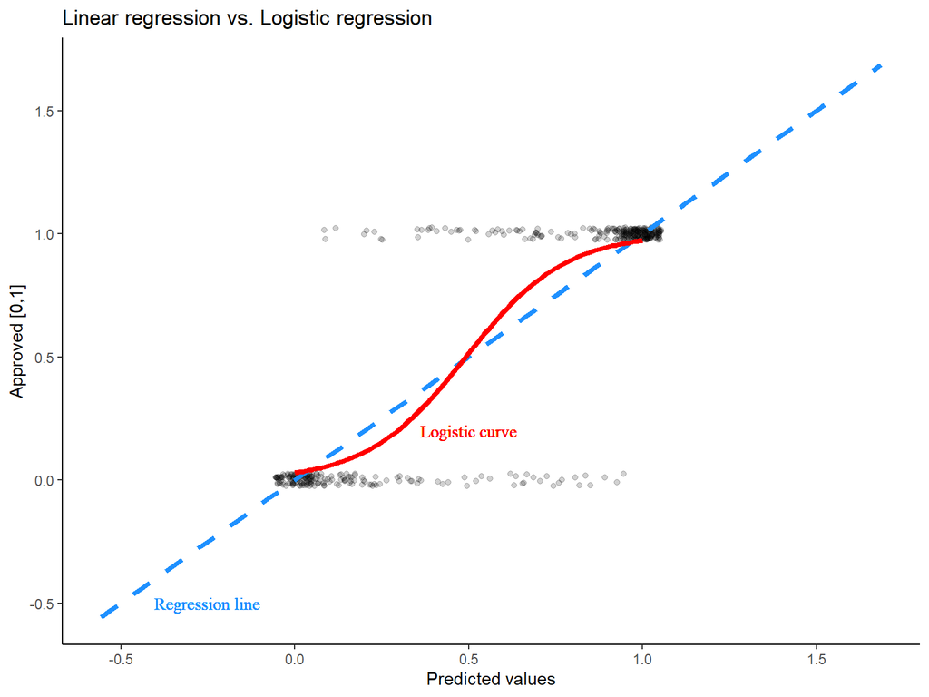

# Diferenças entre regressão logística e regressão linear

- Equação regressão linear

$$\hat{y}_{i} = \beta_{0} +
\beta_{1}x_{1i} +\beta_{n}x_{ni} + \varepsilon_{i}$$

- Equação regressão logística

$$P(Y_{i}) = \frac{1}{1+e^{-(\beta_{0} +
\beta_{1}x_{1i} +\beta_{n}x_{ni})}}$$

# Usos da regressão logística

- Voltando um pouco, sabemos que nosso $Y$ está restrito a um conjunto de $[0,1]$
- Nossas VI’s ($X's$) não estão necessariamente restritos a esses mesmos valores (e.g., escores z)
- O que aquela equação permite é que o $Y$ seja “convertido” de valores (0,1) para $[-\infty, +\infty]$
  - De $Y$ para $P(Y)$ –> Qualquer valor entre 0 e 1
  - De probabilidades para chances –> qualquer valor entre 0 e $\infty$
  - Logarítimo da chance –> Qualquer valor entre $[-\infty, +\infty]$

**Lembrando**

- $Probabilidade = \frac{Evento}{Total}$
- $Chance = \frac{P(Evento)}{P(Não evento)}$
- Log é aquela matéria da escola que todos foram mal, então, apenas um exemplo:

```r
(.7/.3)
```

```
## [1] 2.333333
```

```r
log((.7/.3))
```

```
## [1] 0.8472979
```

```r
(.3/.7)
```

```
## [1] 0.4285714
```

```r
log((.3/.7))
```

```
## [1] -0.8472979
```

| probability | frequency | odds | Log_odds |
| --- | --- | --- | --- |
| .00 | 0/10 | .00 | NA |
| .10 | 1/9 | .111 | -2.197 |
| .30 | 3/7 | .428 | -0.847 |
| .50 | 5/5 | 1.000 | .000 |
| .70 | 7/3 | 2.333 | .847 |
| .90 | 9/1 | 9.000 | 2.197 |
| 1.00 | 10/0 | NA | NA |

# Usos da regressão logística

Resumidamente, os objetivos são:

- Identificação de fatores associados com a VD (ainda é regressão);
- Classificação: possibilita encaixar os casos em categorias e avaliar medidas de acurácia para essa classificação.

# Problemas ao usar regressão logística

- Estamos, de certa forma, iniciando a apresentação dos pressupostos

**Primeira treta**  
- Informação incompleta

```r
set.seed(56744)
data.frame(Y = rbinom(500,prob = .7, size = 1),
           X = rbinom(500,prob = .1, size = 3)) %>%
  xtabs(~., data = .)
```

```
##    X
## Y     0   1   2   3
##   0  99  39   3   0
##   1 250 100   8   1
```

# Problemas ao usar regressão logística

**Segunda treta**

- Separação completa

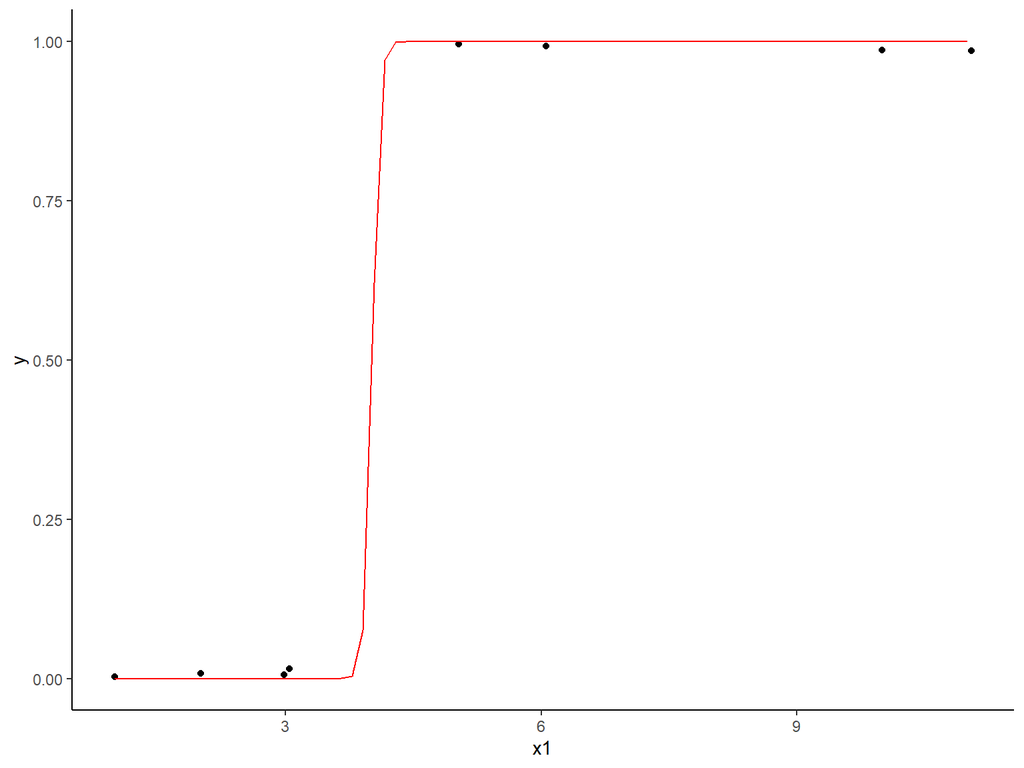

# Problemas ao usar regressão logística

**Terceira treta**  
Superdispersão*  
Essa daqui é mais difícil de entender, talvez faça mais sentido em algum momento posterior em que se estiver trabalhando com dados de contagem. Fica para o futuro.

# Pressupostos

Quais são os pressupostos?  
Abaixo estão listados os principais

1. Variância não nula no $Y$

2. Independência dos erros

3. Linearidade entre os previsores contínuos e o logit da variável Y (Box-Tidwell)

4. Ausência de multicolinearidade

5. Ausência de outliers

# Coeficientes da regressão logística e interpretação

A partir daqui, a coisa pode ficar bem feia dependendo do seu ânimo prévio com a matemática da coisa.  
Os coeficientes da regressão logística são apresentados em *log odds* (daí toda aquela conversa sobre transformação dos dados)  
A interpretação desse tipo de coeficiente é bem complicado, uma vez que não estamos acostumados a pensar em logarítimos

| Parameter | Coefficient | SE | CI | CI_low | CI_high | z | df_error | p |
| --- | --- | --- | --- | --- | --- | --- | --- | --- |
| (Intercept) | -41.758 | 4.735 | 0.95 | -51.979 | -33.323 | -8.819 | Inf | 0 |
| estudo | 0.902 | 0.105 | 0.95 | 0.715 | 1.130 | 8.569 | Inf | 0 |
| notaport | 0.435 | 0.051 | 0.95 | 0.345 | 0.544 | 8.586 | Inf | 0 |

# Coeficientes da regressão logística e interpretação

A interpretação fica mais fácil quando usamos o Odds-ratio (OR) para interpretar os resultados.  
Em alguns programas, esse resultado pode vir com o nome de *Exp(b)*

- O OR indica a associação entre a variável independente e o desfecho em termos de chance. Analisando o intervalo de confiança (IC), os valores de OR são significativos quando não tocam 1. Exemplo de OR significativo: 1,6 (IC 1,2 – 1,8). Exemplo de OR não significativo: 1,6 (IC 0,8 – 1,8).

| Parameter | Coefficient | SE | CI | CI_low | CI_high | z | df_error | p |
| --- | --- | --- | --- | --- | --- | --- | --- | --- |
| (Intercept) | 0.000 | 0.000 | 0.95 | 0.000 | 0.000 | -8.819 | Inf | 0 |
| estudo | 2.466 | 0.260 | 0.95 | 2.043 | 3.094 | 8.569 | Inf | 0 |
| notaport | 1.545 | 0.078 | 0.95 | 1.411 | 1.723 | 8.586 | Inf | 0 |

# Coeficientes da regressão logística e interpretação

*Aprofundando o conhecimento do odds ratio*

- Para uma VI categórica: se eu sou do grupo de referência, eu tenho (valor do odds) vezes mais chance de pertencer ao grupo referência da variável dependente, do que pessoas do grupo não referência da VI. Os odds são razão de chance, quantas vezes um grupo é mais provável de estar na categoria desfecho do que o outro grupo. Essa interpretação é sempre relativa à categoria escolhida como referência. Importante: em casos de OR significativos, mas menores que 1 a interpretação apenas assume o formato de menores chance. Exemplo: OR significativo de 0,6: se estou no grupo de referência da VI, tenho menos chance de estar no grupo de referência da VD. Não podemos fazer a “multiplicação” descrita anteriormente.
- Para uma VI contínua: para cada uma unidade a mais na VI, eu tenho (valor do odds) vezes mais chance de pertencer ao grupo referência da variável dependente.

https://imaging.mrc-cbu.cam.ac.uk/statswiki/FAQ/effectSize

| Odds-ratio | Reference |
| --- | --- |
| 1.5 | Small |
| 3.5 | Moderate |
| 9.0 | Large |

# Avaliação do modelo (ajuste e outras métricas)

- Ajuste geral do modelo: o modelo se ajusta bem aos dados? –> Hosmer-Lemeshow Goodness-of-Fit Test
- O modelo é melhor do que um modelo sem nenhum previsor? –> i.e., o modelo é significativo? –> Teste de qui-quadrado (seu modelo vs. modelo nulo)
- Meu modelo 2 é melhor que meu modelo 1? –> métricas para comparação entre modelos AIC, BIC, Deviance (menores valores indicam melhor ajuste)
- Existe uma variância explicada pelo modelo? –> **Não!** Existem Pseudo R² que tentam simular um R² de regressão linear, mas não apresentam exatamente a mesma funcionalidade. Alguns autores sugerem que eles podem ser entendidos como uma métrica de “tamanho de efeito” geral OU para comparar modelos. Quanto maior, melhor.

# Avaliação do modelo (ajuste e outras métricas)

# Prática - Regressão logística no R

Subindo o banco de dados e inspencionando

```r
pacman::p_load(tidyverse, easystats, car, janitor, jtools)
base <- readRDS(url("https://github.com/Pedro-SR-Martins/GrupoEstudosEstatistica2023/blob/main/bancos/bancolog.rds?raw=true", method="libcurl"))
glimpse(base)
```

```
## Rows: 450
## Columns: 5
## $ passoumat    <fct> passou, passou, passou, passou, passou, passou, não passo…
## $ estudo       <dbl> 15.672950, 17.597983, 17.713997, 17.620254, 13.525502, 10…
## $ notaport     <dbl> 72.75278, 87.43657, 74.50842, 80.97035, 79.68301, 75.3564…
## $ interessemat <fct> 2, 1, 0, 1, 1, 1, 2, 2, 2, 1, 1, 1, 1, 0, 1, 0, 2, 2, 1, …
## $ sexo         <fct> mulher, mulher, homem, homem, homem, mulher, mulher, mulh…
```

# Regressão logística no R

```r
base <- base %>%
  mutate(interessemat = factor(interessemat,
                               levels = c(0,1,2),
                               labels = c("Nenhum",
                                          "Moderado",
                                          "Muito")))
head(base)
```

```
##   passoumat   estudo notaport interessemat   sexo
## 1    passou 15.67295 72.75278        Muito mulher
## 2    passou 17.59798 87.43657     Moderado mulher
## 3    passou 17.71400 74.50842       Nenhum  homem
## 4    passou 17.62025 80.97035     Moderado  homem
## 5    passou 13.52550 79.68301     Moderado  homem
## 6    passou 10.69220 75.35643     Moderado mulher
```

# Regressão logística no R

```r
data.frame(psych::describe(base)) %>% select(n, mean, sd, median, min, max)
```

```
##                 n      mean        sd   median        min      max
## passoumat*    450  1.586667 0.4929797  2.00000  1.0000000  2.00000
## estudo        450 14.001605 4.6552801 13.86144  0.7429546 27.50715
## notaport      450 70.084063 9.9951216 70.45987 35.8702293 98.64430
## interessemat* 450  2.011111 0.7652597  2.00000  1.0000000  3.00000
## sexo*         450  1.677778 0.4678477  2.00000  1.0000000  2.00000
```

```r
psych::describe(base)
```

```
##               vars   n  mean    sd median trimmed  mad   min   max range  skew
## passoumat*       1 450  1.59  0.49   2.00    1.61 0.00  1.00  2.00  1.00 -0.35
## estudo           2 450 14.00  4.66  13.86   14.03 4.93  0.74 27.51 26.76 -0.06
## notaport         3 450 70.08 10.00  70.46   70.13 9.25 35.87 98.64 62.77 -0.09
## interessemat*    4 450  2.01  0.77   2.00    2.01 1.48  1.00  3.00  2.00 -0.02
## sexo*            5 450  1.68  0.47   2.00    1.72 0.00  1.00  2.00  1.00 -0.76
##               kurtosis   se
## passoumat*       -1.88 0.02
## estudo           -0.34 0.22
## notaport          0.30 0.47
## interessemat*    -1.30 0.04
## sexo*            -1.43 0.02
```

```r
base %>%
  select(passoumat, interessemat) %>%
  group_by(passoumat) %>%
  count(interessemat)
```

```
## # A tibble: 6 × 3
## # Groups:   passoumat [2]
##   passoumat  interessemat     n
##   <fct>      <fct>        <int>
## 1 não passou Nenhum          58
## 2 não passou Moderado        75
## 3 não passou Muito           53
## 4 passou     Nenhum          71
## 5 passou     Moderado       112
## 6 passou     Muito           81
```

# Regressão logística no R

Finalmente fazendo o modelo

```r
fit1 <- glm(passoumat ~ sexo + estudo + notaport + interessemat,
            data = base,
            family = binomial("logit"))
```

pesquisar diferença entre logit e probit

# Avaliação de pressupostos

Linearidade

```r
boxTidwell(fit1$linear.predictors ~ estudo + notaport,
              data = base)
```

```
##          MLE of lambda Score Statistic (z) Pr(>|z|)
## estudo          1.0162              0.6569  0.51127
## notaport        1.1192              2.2712  0.02314 *
## ---
## Signif. codes:  0 '***' 0.001 '**' 0.01 '*' 0.05 '.' 0.1 ' ' 1
##
## iterations =  1
```

inspeção visual

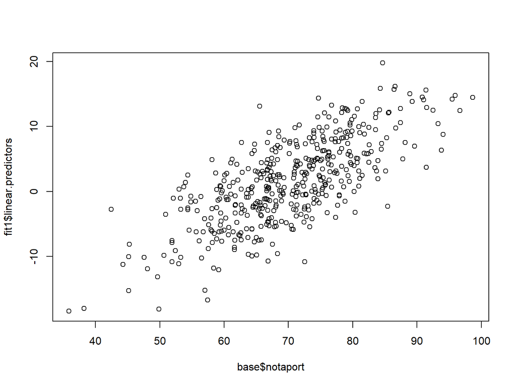

```r
plot(fit1$linear.predictors ~ base$notaport)
```

# Avaliação de pressupostos

Caso as coisas fiquem esquisitas aqui, você deve acrescentar a interação da sua VI com o log dela, algo como:

```r
fit2 <- glm(passoumat ~ sexo + estudo +
              notaport + (notaport * log(notaport))+

            + interessemat,
            data = base,
            family = binomial("logit"))
Anova(fit2)
```

```
## Analysis of Deviance Table (Type II tests)
##
## Response: passoumat
##                        LR Chisq Df Pr(>Chisq)
## sexo                      0.280  1    0.59680
## estudo                  278.809  1    < 2e-16 ***
## notaport                  0.184  1    0.66756
## log(notaport)             0.608  1    0.43570
## interessemat              9.060  2    0.01078 *
## notaport:log(notaport)    0.119  1    0.73058
## ---
## Signif. codes:  0 '***' 0.001 '**' 0.01 '*' 0.05 '.' 0.1 ' ' 1
```

# Avaliação de pressupostos

Independência dos erros

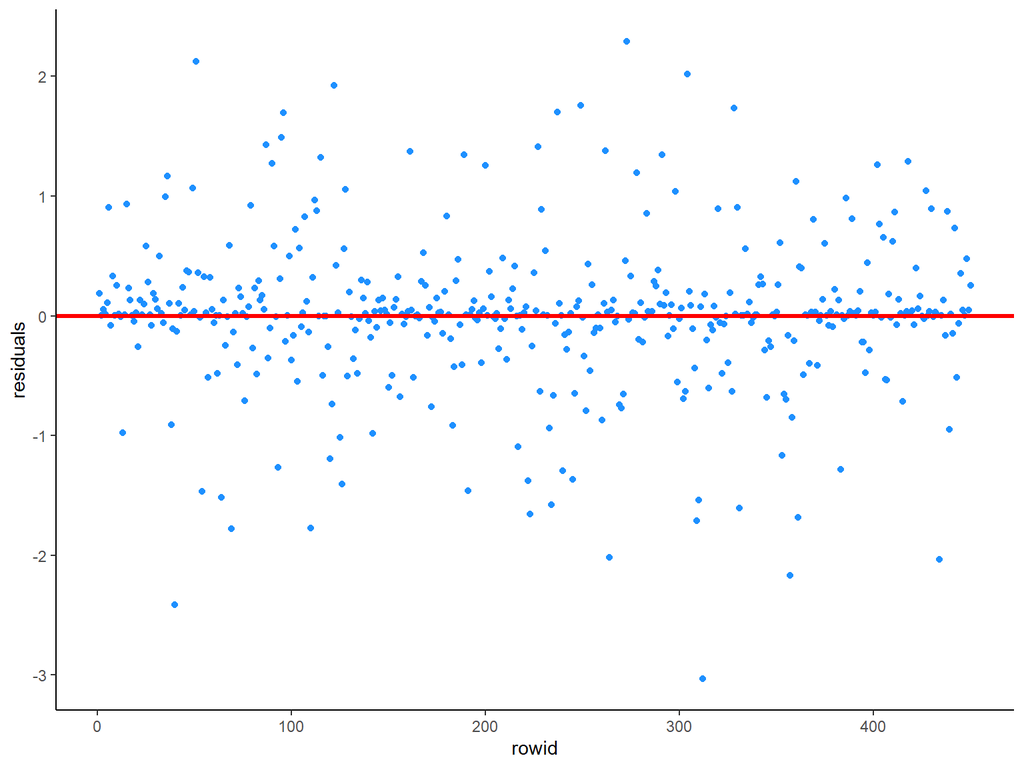

```r
data.frame(residuals = residuals.glm(fitlog, "deviance")) %>%
  rowid_to_column() %>%
  ggplot(aes(x = rowid, y=residuals))+
  geom_point(color = "dodgerblue")+
  geom_hline(yintercept = 0, color = "red", linewidth = 1.2)+
  theme_classic()
```

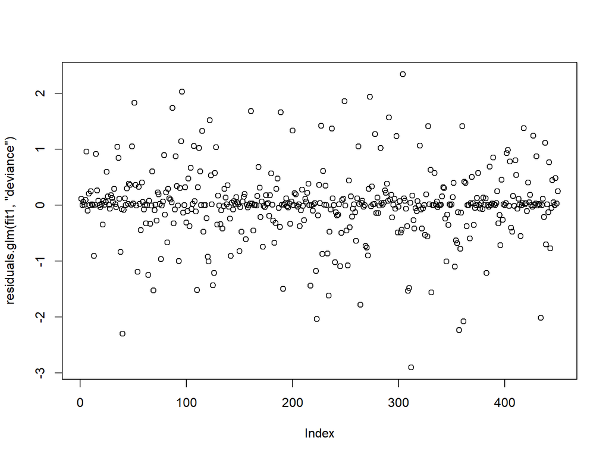

```r
plot(residuals.glm(fit1, "deviance"))
```

# Avaliação de pressupostos

Ausência de multicolinearidade

Até 5 pode ser considerado aceitável. Mas os valores poderiam ser melhores…

```r
vif(fit1)
```

```
##                  GVIF Df GVIF^(1/(2*Df))
## sexo         1.013810  1        1.006881
## estudo       4.250373  1        2.061643
## notaport     4.264731  1        2.065123
## interessemat 1.116516  2        1.027936
```

# Breve introdução a outliers

```r
check_outliers(fit1)
```

```
## OK: No outliers detected.
## - Based on the following method and threshold: cook (0.89).
## - For variable: (Whole model)
```

# Breve introdução a outliers

```r
# define crit betas as Belsley et al. 1980
critbetas <- 2/sqrt(NROW(base))
critbetas
```

```
## [1] 0.0942809
```

```r
dfbeta(fit1) %>% psych::describe() %>% data.frame() %>% select(min,max)
```

```
##                              min         max
## (Intercept)          -0.33494031 0.971333995
## sexomulher           -0.08553285 0.090520158
## estudo               -0.02357605 0.008585850
## notaport             -0.01209463 0.004801646
## interessematModerado -0.08917117 0.084089197
## interessematMuito    -0.11706238 0.100055861
```

# Regressão logística no R

```r
summary(fit1)
```

```
##
## Call:
## glm(formula = passoumat ~ sexo + estudo + notaport + interessemat,
##     family = binomial("logit"), data = base)
##
## Deviance Residuals:
##      Min        1Q    Median        3Q       Max
## -2.90104  -0.12989   0.00749   0.17160   2.34256
##
## Coefficients:
##                       Estimate Std. Error z value Pr(>|z|)
## (Intercept)          -44.77293    5.18028  -8.643  < 2e-16 ***
## sexomulher            -0.18613    0.41381  -0.450  0.65285
## estudo                 0.95900    0.11400   8.412  < 2e-16 ***
## notaport               0.46116    0.05494   8.394  < 2e-16 ***
## interessematModerado   0.50044    0.45380   1.103  0.27012
## interessematMuito      1.48076    0.52597   2.815  0.00487 **
## ---
## Signif. codes:  0 '***' 0.001 '**' 0.01 '*' 0.05 '.' 0.1 ' ' 1
##
## (Dispersion parameter for binomial family taken to be 1)
##
##     Null deviance: 610.24  on 449  degrees of freedom
## Residual deviance: 174.78  on 444  degrees of freedom
## AIC: 186.78
##
## Number of Fisher Scoring iterations: 8
```

# Regressão logística no R

```r
summ(fit1, exp = T, confint = T, digits = 3)
```

| Observations | 450 |
| --- | --- |
| Dependent variable | passoumat |
| Type | Generalized linear model |
| Family | binomial |
| Link | logit |

| χ²(5) | 435.465 |
| --- | --- |
| Pseudo-R² (Cragg-Uhler) | 0.835 |
| Pseudo-R² (McFadden) | 0.714 |
| AIC | 186.779 |
| BIC | 211.435 |

|  | exp(Est.) | 2.5% | 97.5% | z val. | p |
| --- | --- | --- | --- | --- | --- |
| (Intercept) | 0.000 | 0.000 | 0.000 | -8.643 | 0.000 |
| sexomulher | 0.830 | 0.369 | 1.868 | -0.450 | 0.653 |
| estudo | 2.609 | 2.087 | 3.262 | 8.412 | 0.000 |
| notaport | 1.586 | 1.424 | 1.766 | 8.394 | 0.000 |
| interessematModerado | 1.649 | 0.678 | 4.014 | 1.103 | 0.270 |
| interessematMuito | 4.396 | 1.568 | 12.325 | 2.815 | 0.005 |

Standard errors: MLE

# Regressão logística no R

Efeitos principais

```r
Anova(fit1)
```

```
## Analysis of Deviance Table (Type II tests)
##
## Response: passoumat
##              LR Chisq Df Pr(>Chisq)
## sexo            0.203  1    0.65243
## estudo        279.430  1    < 2e-16 ***
## notaport      272.104  1    < 2e-16 ***
## interessemat    8.629  2    0.01338 *
## ---
## Signif. codes:  0 '***' 0.001 '**' 0.01 '*' 0.05 '.' 0.1 ' ' 1
```

# Regressão logística no R

```r
performance_hosmer(fit1)
```

```
## # Hosmer-Lemeshow Goodness-of-Fit Test
##
##   Chi-squared: 1.628
##            df: 8
##       p-value: 0.990
```

```
## Summary: model seems to fit well.
```

# Regressão logística no R

```r
performance_pcp(fit1, method = "Gelman-Hill")
```

```
## # Percentage of Correct Predictions from Logistic Regression Model
##
##   Full model: 90.89% [88.23% - 93.55%]
##   Null model: 58.67% [54.12% - 63.22%]
##
## # Likelihood-Ratio-Test
##
##   Chi-squared: 435.465
##   df:   5.000
##   p-value:   0.000
```

```r
#method = "Gelman-Hill" -- > acima de .5 é predito como 1
```

# Regressão logística no R

```r
predicted <- predict(fit1, base, type = "response")
predicted <- ifelse(predicted > 0.5, 1, 0)
# Convert to factor: p_class
predicted <- factor(predicted,
                  levels = c(0,1),
                  labels = levels(base$passoumat))
caret::confusionMatrix(reference = base$passoumat,
                       data = predicted,
                       positive = "passou")
```

```
## Confusion Matrix and Statistics
##
##             Reference
## Prediction   não passou passou
##   não passou        165     20
##   passou             21    244
##
##                Accuracy : 0.9089
##                  95% CI : (0.8784, 0.9338)
##     No Information Rate : 0.5867
##     P-Value [Acc > NIR] : <2e-16
##
##                   Kappa : 0.812
##
##  Mcnemar's Test P-Value : 1
##
##             Sensitivity : 0.9242
##             Specificity : 0.8871
##          Pos Pred Value : 0.9208
##          Neg Pred Value : 0.8919
##              Prevalence : 0.5867
##          Detection Rate : 0.5422
##    Detection Prevalence : 0.5889
##       Balanced Accuracy : 0.9057
##
##        'Positive' Class : passou
##
```

# Visualizando o modelo

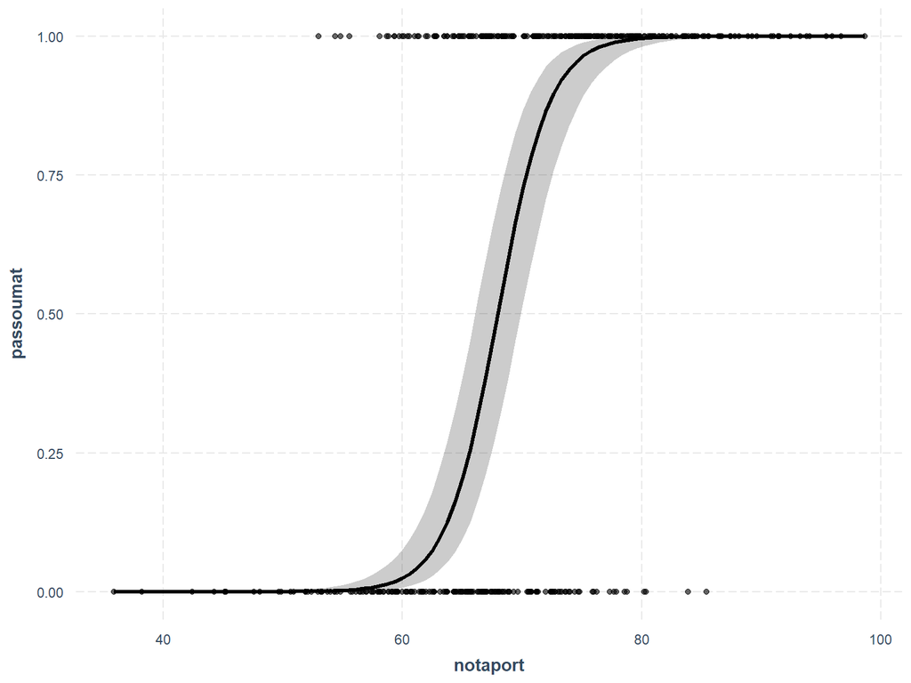

```r
effect_plot(fit1, pred = notaport,
            plot.points = T,
            interval = T)
```

# Visualizando o modelo

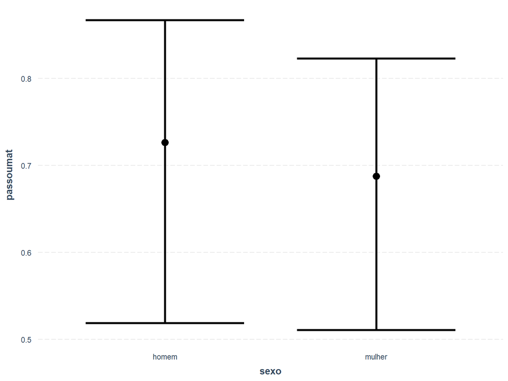

```r
effect_plot(fit1, pred = sexo,
            interval = T)
```

# Adendo outliers

```r
source("https://raw.githubusercontent.com/Pedro-SR-Martins/my_funs/main/aux_glm")
outresults <- glm_out(fit1)
```

```
## [1] "a total of 10 outliers should be excluded, i.e., cases that met the two criteria"
```

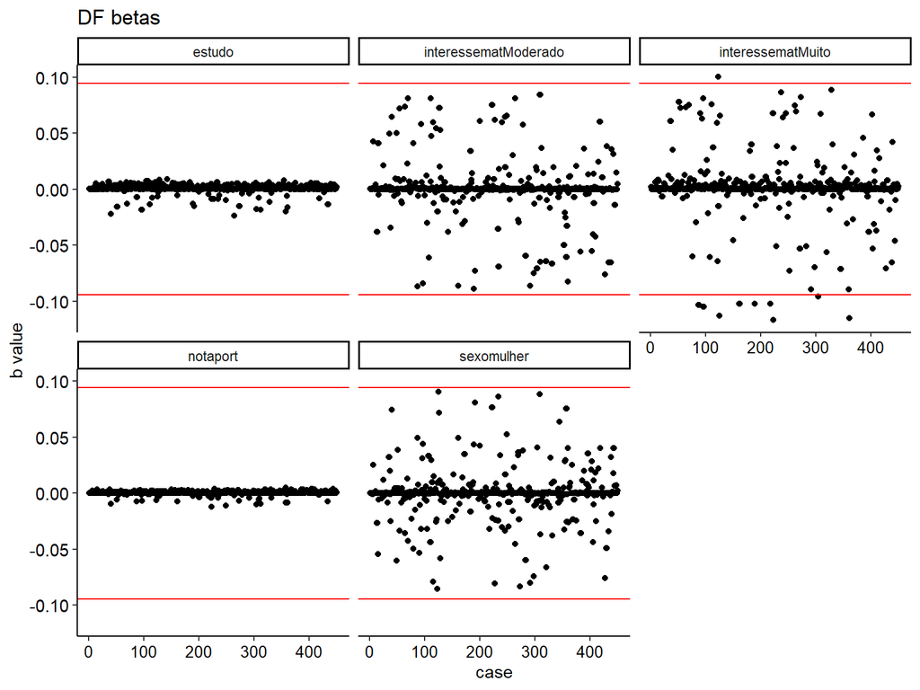

```r
outresults$plot_betas
```

```r
outresults$noout_data %>% head()
```

```
## # A tibble: 6 × 5
##   passoumat sexo   estudo notaport interessemat
##   <fct>     <fct>   <dbl>    <dbl> <fct>
## 1 passou    mulher   15.7     72.8 Muito
## 2 passou    mulher   17.6     87.4 Moderado
## 3 passou    homem    17.7     74.5 Nenhum
## 4 passou    homem    17.6     81.0 Moderado
## 5 passou    homem    13.5     79.7 Moderado
## 6 passou    mulher   10.7     75.4 Moderado
```

# Referências

- Fávero, L. P., & Belfiore, P. (2017). Manual de análise de dados: estatística e modelagem multivariada com Excel®, SPSS® e Stata®. Elsevier Brasil.
- Field, A. (2018). Discovering Statistics Using IBM SPSS Statistics. Discovering Statistics Using IBM SPSS Statistics.
- Gelman, A., Hill, J., & Vehtari, A. (2020). Regression and other stories. Cambridge University Press.
- Long, J. S., & Freese, J. (2014). Regression models for categorical dependent variables using Stata (Vol. 7). Stata press.
- Hair Jr, J. F., Black, W. C., Babin, B. J., & Anderson, R. E. (2019). Multivariate data analysis.